## MA2102

# Probability and Statistics

#### Lecture-5

From the relative frequency definition we can observe three basic properties of chance,that are  
i). $\frac{f_{n}(E)}{n}\ge0~\forall~E\Rightarrow P(E)=\lim_{n \to \infty}\frac{f_{n}(E)}{n}\ge0 \leftarrow$ **Non-negativity property**  
ii). $f_{n}(\Omega)=n\Rightarrow P(\Omega)=\lim_{n \to \infty}\frac{f_{n}(\Omega)}{n}=\lim_{n \to \infty}1=1 \leftarrow$**Certainty property**  
iii). If $E_{1}\cap E_{2}=\emptyset$ then $f_{n}(E_{1}\cup E_{2})=f_{n}(E_{1})+f_{n}(E_{2})$  
then $P(E_{1}\cup E_{2})=\lim_{n \to \infty} \frac{f_{n}(E_{1}\cup E_{2})}{n}=\lim_{n \to \infty} \frac{f_{n}(E_{1})+f_{n}(E_{2})}{n}=\lim_{n \to \infty} \frac{f_{n}(E_{1})}{n} + \lim_{n \to \infty} \frac{f_{n}(E_{2})}{n}=P(E_{1})+P(E_{2})$  
$\therefore P(E_{1}\cup E_{2})=P(E_{1})+P(E_{2}) \leftarrow$ **Additive property**

**Axiomatic definition of probability:**  
Let $(\Omega,\mathscr{F})$ be a measurable space, a set function $P:\mathscr{F}\rightarrow \mathbb{R}$ is called a probability(measure) function on $(\Omega,\mathscr{F})$ if it satisfies the following axioms.  
*Axiom 1*:$P(E)\ge0$ $\forall E\in\mathscr{F}$ **(Non-negativity axiom)**  
*Axiom 2*:$P(\Omega)=1$ **(Certainty axiom)**  
*Axiom 3*: For any sequence of events $E_{1},E_{2},E_{3},...,E_{n}....$ in $\mathscr{F}$ such that $E_{i}\cap E_{j}=\emptyset$ for $i\ne j$ then,  
$P(\bigcup_{i=1}^{\infty}E_{i})=\sum_{i=1}^{\infty}P(E_{i})$ **(Countable additivity axiom)**

Here the triple $(\Omega,\mathscr{F},P)$ is called a probability space(or probability model)

Let $I$ be an index set,

- Collection of events $\{E_{i}\}_{i\in I}$ in $\mathscr{F}$, are said to be mutually exclusive if $E_{i}\cap E_{j}=\emptyset$ for $i \ne j$ (At most on event in collection can occur when we performs an experiment which means no two events in the collection can happen simultaneously)
- Collection of events $\{E_{i}\}_{i\in I}$ in $\mathscr{F}$, are said to be exhaustive if $\bigcup_{i\in I}E_{i}=\Omega$ (At least one event in collection always occur when we performs an experiment)
- Collection of events $\{E_{i}\}_{i\in I}$ in $\mathscr{F}$, are said to form a partition for $\Omega$ if they are both mutually exclusive and exhaustive (Exactly one event in collection can occur when we performs an experiment)

In all of the following theorems we consider probability space $(\Omega,\mathscr{F},P)$

**Theorem 1:** $P(\emptyset)=0$  
*proof*: Take $E_{1}=\Omega$, and $E_{i}=\emptyset$ for i=2,3,4,...  
$\Omega=\bigcup_{i=1}^{\infty}E_{i}$ and $E_{i}\cap E_{j}=\emptyset$ for $i \ne j$  
$P(\Omega)=P(\bigcup_{i=1}^{\infty}E_{i})$  
$=\sum_{i=1}^{\infty}P(E_{i})$ ($\because$ Axiom (3) )  
$=P(E_{1})+P(E_{2})+P(E_{3})+...$  
$P(\Omega)=P(\Omega)+P(\emptyset)+P(\emptyset )+...$  
$1=1+P(\emptyset )+P(\emptyset )+...$ ($\because$ Axiom (2) )  
$0=P(\emptyset )+P(\emptyset )+...$  
so only real number that make sense as $P(\emptyset)$ is zero ($\because P(\emptyset)\ge0$ by Axiom (1))  
$\therefore P(\emptyset)=0$

**Theorem 2** (Finite Additivity): For any finite collection $E_{1},E_{2},...,E_{n}$ in $\mathscr{F}$ such that $E_{i}\cap E_{j}=\emptyset$ for $i \ne j$, then $P(\bigcup_{i=1}^{n}E_{i})=\sum_{i=1}^{n}P(E_{i})$  
*proof*: Take $E_{n+i}=\emptyset$ for i=1,2,3,...  
now, $\bigcup_{i=1}^{n}E_{i}=\bigcup_{i=1}^{\infty}E_{i}$ and. $E_{i}\cap E_{j}=\emptyset$ for $i \ne j$  
$P(\bigcup_{i=1}^{n}E_{i})=P(\bigcup_{i=1}^{\infty}E_{i})$  
$=\sum_{i=1}^{\infty}P(E_{i})$ ($\because$ Axiom 3)  
$=\sum_{i=1}^{n}P(E_{i})+\sum_{i=n+1}^{\infty}P(E_{i})$ $=\sum_{i=1}^{n}P(E_{i})+\sum_{i=n+1}^{\infty}P(\emptyset )=\sum_{i=1}^{n}P(E_{i})+\sum_{i=n+1}^{\infty}0$ ($\because$ Theorem 1)  
$\therefore P(\bigcup_{i=1}^{n}E_{i})=\sum_{i=1}^{n}P(E_{i})$ whenever $E_{1},E_{2},...,E_{n}$ are mutually exclusive

**Theorem 3:** For any $E \in \mathscr{F}$, $P(E^{c})=1-P(E)$  
*proof*: $E\cup E^{c}=\Omega \Rightarrow P(E\cup E^{c})=P(\Omega)\Rightarrow P(E)+P(E^{c})=1$ ($\because E\cap E^{c}=\emptyset$, Finite additivity. Axiom 2)  
$\therefore P(E^{c})=1-P(E)$

**Theorem 4:** For any two events $E_{1},E_{2}\in \mathscr{F}$, then $P(E_{1}\cap E_{2}^{c})=P(E_{1})-P(E_{1}\cap E_{2})$  
*proof:*

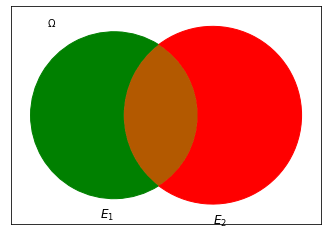

```python
# First install matplotlib-venn
#pip install matplotlib-venn
from matplotlib import pyplot as plt
from matplotlib_venn import venn2

# Basic Venn
v = venn2( (10,12,5), alpha = 1,set_labels = (r'$E_1$', r'$E_2$') )
v.get_patch_by_id('10').set_color('green')
v.get_label_by_id('10').set_text('')
v.get_patch_by_id('01').set_color('red')
v.get_label_by_id('11').set_text('')
v.get_label_by_id('01').set_text('')
plt.gca().set_axis_on()
plt.text(-0.6,0.45,r"$\Omega$")

# Show it
plt.show()
```

$E_{1}=$$(E_{1}\cap E_{2}^{c})$ $\cup$$(E_{1}\cap E_{2})$
$P(E_{1})=P((E_{1}\cap E_{2}^{c})\cup (E_{1}\cap E_{2}))$
Here $E_{1}\cap E_{2}^{c}$ and $E_{1}\cap E_{2}$ are mutually exclusive, so by finite additivity, we have
$P(E_{1})=P(E_{1}\cap E_{2}^{c})+ P(E_{1}\cap E_{2})$
$\therefore P(E_{1}\cap E_{2}^{c})= P(E_{1})- P(E_{1}\cap E_{2})$

**Corollary 1:** If $E_{2}\subseteq E_{1}$ then $P(E_{1}\cap E_{2}^{c})= P(E_{1})-P(E_{2}) ~~(\because E_{1}\cap E_{2}=E_{2}$)

**Corollary 2** (Monotone property): If $E_{2}\subset E_{1}$ then $P(E_{2})\le P(E_{1})$  
*proof*: Here $E_{2}\subset E_{1} \Rightarrow P(E_{1})-P(E_{2})=P(E_{1}\cap E_{2}^{c})\ge0$ ($\because$ Axiom 1)  
$\because P(E_{2})\le P(E_{1})$

**Theorem 5:** For any event $E\in \mathscr{F}$, $0\le P(E) \le 1$  
*proof*: we know that $\emptyset \subset E \subset \Omega$ for any $E\in \mathscr{F}$  
$\Rightarrow P(\emptyset )\le P(E) \le P(\Omega)$ ($\because$ Monotone property)  
$\therefore 0\le P(E)\le1$ ($\because$ Theorem 1 and Axiom 2)

**Equally likely events**:  
If $E_{1},E_{2},...E_{k}$ are mutually exclusive and exhaustive (*thus form a partition for $\Omega$*) in $\mathscr{F}$, and random experiment is of such a character that we don't prefer one event over the other, that is it is reasonable to assume that each of $E_{1},E_{2},...E_{k}$ has same probability of occurrence. Then we say events $E_{1},E_{2},...E_{k}$ are equally likely.  
*Example 1*:In a random experiment of picking a number from set {0,1,2,3,...}, then the sample space $\Omega=\{0,1,2,3,...\}$, we fix n,  
and take $E_{i}=\{k\in \Omega: n$ divides $(k-i)\}$ for i=0,1,2,3,...  
($E_{i}$ contains all numbers in $\Omega$ that leaves reminder i when it is divided by n.).  
Here it is reasonable to assume that $E_{0},E_{1},E_{2},...E_{n-1}$ are equally likely events.  
*Example 2*:In a random experiment of picking a card from well shuffled pack of cards, and take  
$E_{♠️}\leftarrow$ getting spade card.  
$E_{♣️}\leftarrow$ getting clubs card.  
$E_{❤️}\leftarrow$ getting heart card.  
$E_{♦️}\leftarrow$ getting diamond card.  
Here $E_{♠️},E_{♣️},E_{❤️}$and $E_{♦️}$ are equally likely events

**Theorem 6:** If $E_{1},E_{2},E_{3},...E_{n}$ are equally likely events in $\mathscr{F}$, then $P(E_{i})=\frac{1}{n}\forall i$=1,2..n  
*proof*: $\bigcup_{i=1}^{n}E_{i}=\Omega$ and $E_{i}\cap E_{j}=\emptyset$ for $i\ne j$ and $P(E_{i})=a~\forall$ i=1..n where $a\in (0,1)$  
($\because$ equally likely events form partition for sample space, and events have same probability)  
$P(\bigcup_{i=1}^{n}E_{i})=P(\Omega)$  
$\sum_{i=1}^{n}P(E_{i})=1$ ($\because$ Finite additivity and Axiom 2)  
$\sum_{i=1}^{n}a=1 \Rightarrow na=1 \Rightarrow a=\frac{1}{n}$  
$\therefore P(E_{i})=\frac{1}{n}$ $\forall i=$1...n

**Corollary:** In a probability space ($\Omega,\mathscr{F},P$), if $\Omega$ is finite and outcomes are equally likely (i.e all singleton events(a.k.a elementary events) are equally likely), for any $E\in \mathscr{F}$, $P(E)=\frac{|E|}{|\Omega|}$  
*proof:* let $\Omega=\{\omega_{1},\omega_{2},...\omega_{n}\}$ and take $E_{i}=\{\omega_{i}\}$ for $i= 1,2,...n$  
then $E_{1},E_{2},E_{3},...E_{n}$ are equally likely, so $P(E_{i})=\frac{1}{n}$ for $i=1,2,3 ...n$  
For any event $E \in \mathscr{F}$, $E=\{ \omega_{i_{1}},\omega_{i_{2}},...\omega_{i_{r}} \}$ where $|E|=r$ for some $\{i_1,i_2,...,i_r\}\subseteq \{1,2,...,n\}$ ($\because E\subseteq \Omega$ )  
i.e $E=\bigcup_{k=1}^{r}E_{i_{k}} \Rightarrow P(E)=P(\bigcup_{k=1}^{r}E_{i_{k}}) =\sum_{k=1}^{r}P(E_{i_{k}})=\sum_{k=1}^{r}\frac{1}{n}=\frac{r}{n}$  
$\therefore P(E)=\frac{|E|}{|\Omega|}$  
This also referred as classical definition of probability,and this approach make sense only if sample space finite and outcomes are equally likely.

**Theorem 7:** (Addition theorem of probability) For any two events $E_{1},E_{2}\in \mathscr{F}$, $P(E_{1}\cup E_{2})=P(E_{1})+P(E_{2})-P(E_{1}\cap E_{2})$

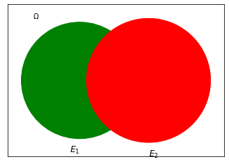

```python
# First you need install matplotlib-venn uisng following
#pip install matplotlib-venn
from matplotlib import pyplot as plt
from matplotlib_venn import venn2

# Basic Venn
v = venn2( (10,12,5), alpha = 1 ,set_labels = (r'$E_1$', r'$E_2$'))
v.get_patch_by_id('10').set_color('green')
v.get_label_by_id('10').set_text('')
v.get_patch_by_id('01').set_color('red')
v.get_label_by_id('11').set_text('')
v.get_label_by_id('01').set_text('')
v.get_patch_by_id('11').set_color('red')
plt.gca().set_axis_on()
plt.text(-0.6,0.45,r"$\Omega$")

# Show it
plt.show()
```

*proof:*  
$E_{1}\cup E_{2}=$ $(E_{1}\cap E_{2}^{c})$ $\cup$ $E_{2}$  
$P(E_{1}\cup E_{2})=P((E_{1}\cap E_{2}^{c}) \cup E_{2})$  
Here $E_{1}\cap E_{2}^{c}$, and $E_{2}$ are mutually exclusive.  
$P(E_{1}\cup E_{2})=P(E_{1}\cap E_{2}^{c}) + P(E_{2})$ ($\because$ Additive property)  
$=P(E_{1})- P(E_{1}\cap E_{2})+P(E_{2})$ ($\because$ Theorem 4)  
$\therefore P(E_{1}\cup E_{2})=P(E_{1})+P(E_{2})- P(E_{1}\cap E_{2})$

**Corollary:** For any three events $E_{1},E_{2},E_{3} \in \mathscr{F}$,  
$P(E_{1}\cup E_{2}\cup E_{3})=P(E_{1})+P(E_{2})+P(E_{3})-P(E_{1}\cap E_{2})-P(E_{2}\cap E_{3})-P(E_{1}\cap E_{3})+P(E_{1}\cap E_{2} \cap E_{3})$  
*proof:* $P(E_{1}\cup E_{2} \cup E_{3})= P(E_{1}\cup (E_{2} \cup E_{3}))$  
$=P(E_{1})+P(E_{2}\cup E_{3})- P(E_{1}\cap (E_{2}\cup E_{3}))$ ($\because$ Addition theorem of probability)  
$=P(E_{1})+P(E_{2}\cup E_{3})- P((E_{1}\cap E_{2})\cup( E_{1}\cap E_{3}))$  
$=P(E_{1})+P(E_{2})+P(E_{3})- P(E_{2}\cap E_{3})-\left[ P(E_{1}\cap E_{2})+P(E_{1} \cap E_{3})- P(E_{1}\cap E_{2}\cap E_{3})\right ]$  
$\therefore P(E_{1}\cup E_{2}\cup E_{3})=P(E_{1})+P(E_{2})+P(E_{3})-P(E_{1}\cap E_{2})-P(E_{2}\cap E_{3})-P(E_{1}\cap E_{3})+P(E_{1}\cap E_{2} \cap E_{3})~$

**Theorem 8** (Inclusion and exclusion principle):For any events $E_{1},E_{2},...,E_{n}$ in $\mathscr{F}$  
$P(\cup_{i=1}^{n}E_{i})=\sum_{1\le i\le n}P(E_{i})-\sum_{1\le i<j\le n}P(E_{i}\cap E_{j})+\sum_{1\le i<j<k\le n}P(E_{i}\cap E_{j} \cap E_{k})-....+(-1)^{r-1}\sum_{1\le i_{1}<i_{2}<...<i_{r}\le n}P(E_{i_{1}}\cap E_{i_{2}}\cap...\cap E_{i_{r}})+...+(-1)^{n-1}P(E_{1}\cap E_{2}\cap...\cap E_{n})$  
*proof*: By induction on n (you can try!)

Problem 1: If 4 married couple are seated at random around round table, compute the probability that no wives sit next to her husband.

*solution* :  
Here we assume that all outcomes(arrangements) are equally likely as they are sitting at random. and  
sample space $\Omega=$ all circular arrangements of 8 people.  
and $|\Omega|=(8-1)!=7!$  
Let $E_{i}$ denote the event that $i^{th}$ couple sitting together for $i$=1,2,3,4  
Our event of interest can be expressed in terms of $E_{i}$'s as follows,  
$\bigcap_{i=1}^{4}E_{i}^{c} \leftarrow$ no couple sitting together.  
now, $P(\bigcap_{i=1}^{4}E_{i}^{c})=1-P(\bigcup_{i=1}^{4}E_{i})$ ($\because \bigcap_{i=1}^{4}E_{i}^{c}=(\bigcup_{i=1}^{4}E_{i})^{c}$ (De Morgan's law) and $P(E^{c})=1-P(E)$)  
=1-$\left[ \sum_{1\le i\le 4}P(E_{i})-\sum_{1\le i<j\le 4}P(E_{i}\cap E_{j})+\sum_{1\le i<j<k\le 4}P(E_{i}\cap E_{j} \cap E_{k})-P(E_{1}\cap E_{2}\cap E_{3}\cap E_{4}) \right]$ ($\because$ principle of inclusion and exclusion)  
now $|E_{i}|=2!\times 6! \Rightarrow P(E_{i})=\frac{2!\times 6!}{7!}=\frac{30}{105}$ for $i=$1,2,3,4  
$|E_{i}\cap E_{j}|=(2!)^{2}\times 5! \Rightarrow P(E_{i}\cap E_{j})=\frac{(2!)^{2}\times 5!}{7!}=\frac{10}{105}$ for $i\ne j$  
$|E_{i}\cap E_{j} \cap E_{k}|=(2!)^{3}\times 4! \Rightarrow P(E_{i}\cap E_{j} \cap E_{k})=\frac{(2!)^{3}\times 4!}{7!}=\frac{4}{105}$  
$|E_{1}\cap E_{2} \cap E_{3} \cap E_{4}|=(2!)^{4}\times 3! \Rightarrow P(E_{1}\cap E_{2} \cap E_{3}\cap E_{4})=\frac{(2!)^{4}\times 3!}{7!}=\frac{2}{105}$  
$P(\bigcap_{i=1}^{4}E_{i}^{c})=1-\left[ \sum_{1\le i\le 4}\frac{30}{105}-\sum_{1\le i<j\le 4}\frac{10}{105}+\sum_{1\le i<j<k\le 4}\frac{4}{105}-\frac{2}{105} \right]$  
$=1-\left[ \binom{4}{1}\frac{30}{105}-\binom{4}{2}\frac{10}{105}+\binom{4}{3}\frac{4}{105}-\frac{2}{105} \right] = 0.295$  
$\therefore P$(no wives sit next to her husband)=0.295

Problem 2: A bowl contains 16 chips, of which 6 are red, 7 are white and 3 are blue. If four chips are taken at random without replacement, find the probability that, (a) each of the four chips is red; (b)none of the chips is red; (c)there is at least one chip of each color.

*solution:*  
We draw four chips at random without replacement from the bowl that contains 16 chips.  
Let $\Omega$ be a sample space, $|\Omega|=\binom{16}{4}=1820$  
Since chips are taken at random, we can assume all possible outcomes are equally likely.  
a). Let A denote the event that each of the four drawn chips is red.  
$|A|=\binom{6}{4}\binom{7}{0}\binom{3}{0}=15$  
$\therefore P(A)=\frac{|A|}{|\Omega|}=\frac{15}{1820}\approx0.00824$  
b). Let B denote the event that none of the chip is red.  
$|B|=\binom{6}{0}\binom{7+3}{4}=\binom{10}{4}=210$  
$\therefore P(B)=\frac{|B|}{|\Omega|}=\frac{210}{1820}\approx0.1153$  
c). Let C denote the event that at least one chip of each color  
$|C|=\binom{6}{1}\binom{7}{1}\binom{3}{2}+\binom{6}{1}\binom{7}{2}\binom{3}{1}+\binom{6}{2}\binom{7}{1}\binom{3}{1}=819$  
$\therefore P(C)=\frac{|C|}{|\Omega|}=\frac{819}{1820}\approx0.45$